# Shooting Project

2025-01-31

# Importing the data

```r
url <- "https://data.cityofnewyork.us/api/views/833y-fsy8/rows.csv"
shootings_raw <- read_csv(url) %>%
  clean_names() # Janitor turns every column name to snake_case
```

# Describing the data

```r
shootings_raw %>% glimpse()
```

```
## Rows: 28,562
## Columns: 21
## $ incident_key            <dbl> 231974218, 177934247, 255028563, 25384540, 726…
## $ occur_date              <chr> "08/09/2021", "04/07/2018", "12/02/2022", "11/…
## $ occur_time              <time> 01:06:00, 19:48:00, 22:57:00, 01:50:00, 01:58…
## $ boro                    <chr> "BRONX", "BROOKLYN", "BRONX", "BROOKLYN", "BRO…
## $ loc_of_occur_desc       <chr> NA, NA, "OUTSIDE", NA, NA, NA, NA, NA, NA, NA,…
## $ precinct                <dbl> 40, 79, 47, 66, 46, 42, 71, 69, 75, 69, 40, 42…
## $ jurisdiction_code       <dbl> 0, 0, 0, 0, 0, 2, 0, 2, 0, 0, 0, 2, 0, 0, 2, 0…
## $ loc_classfctn_desc      <chr> NA, NA, "STREET", NA, NA, NA, NA, NA, NA, NA, …
## $ location_desc           <chr> NA, NA, "GROCERY/BODEGA", "PVT HOUSE", "MULTI …
## $ statistical_murder_flag <lgl> FALSE, TRUE, FALSE, TRUE, TRUE, FALSE, TRUE, F…
## $ perp_age_group          <chr> NA, "25-44", "(null)", "UNKNOWN", "25-44", "18…
## $ perp_sex                <chr> NA, "M", "(null)", "U", "M", "M", NA, NA, "M",…
## $ perp_race               <chr> NA, "WHITE HISPANIC", "(null)", "UNKNOWN", "BL…
## $ vic_age_group           <chr> "18-24", "25-44", "25-44", "18-24", "<18", "18…
## $ vic_sex                 <chr> "M", "M", "M", "M", "F", "M", "M", "M", "M", "…
## $ vic_race                <chr> "BLACK", "BLACK", "BLACK", "BLACK", "BLACK", "…
## $ x_coord_cd              <dbl> 1006343.0, 1000082.9, 1020691.0, 985107.3, 100…
## $ y_coord_cd              <dbl> 234270.0, 189064.7, 257125.0, 173349.8, 247502…
## $ latitude                <dbl> 40.80967, 40.68561, 40.87235, 40.64249, 40.845…
## $ longitude               <dbl> -73.92019, -73.94291, -73.86823, -73.99691, -7…
## $ lon_lat                 <chr> "POINT (-73.92019278899994 40.80967347200004)"…
```

### Key variables definition:

- boro: Borough where the shooting incident occurred.
- precinct: a district of a city or town as defined for police purposes.
- jurisdiction code: Jurisdiction where the shooting incident occurred. Jurisdiction codes 0(Patrol), 1(Transit) and 2(Housing) represent NYPD whilst codes 3 and more represent non NYPD jurisdictions.
- statistical murder flag: Shooting resulted in the victim’s death which would be counted as a murder.

Note: Other variables were considered self-explanatory according to their names.

# Transforming the data

```r
shootings_raw %>% count(jurisdiction_code)
```

| jurisdiction_code | n |
| --- | --- |
| 0 | 23923 |
| 1 | 81 |
| 2 | 4556 |
| NA | 2 |

```r
shootings_raw %>% count(loc_classfctn_desc)
```

| loc_classfctn_desc | n |
| --- | --- |
| (null) | 2 |
| COMMERCIAL | 208 |
| DWELLING | 243 |
| HOUSING | 460 |
| OTHER | 59 |
| PARKING LOT | 15 |
| PLAYGROUND | 41 |
| STREET | 1886 |
| TRANSIT | 23 |
| VEHICLE | 29 |

[output cut: 1 more lines]

```r
shootings_raw %>% count(location_desc, sort = TRUE)
```

| location_desc | n |
| --- | --- |
| NA | 14977 |
| MULTI DWELL - PUBLIC HOUS | 5007 |
| MULTI DWELL - APT BUILD | 2964 |
| (null) | 1711 |
| PVT HOUSE | 983 |
| GROCERY/BODEGA | 750 |
| BAR/NIGHT CLUB | 668 |
| COMMERCIAL BLDG | 304 |
| RESTAURANT/DINER | 212 |
| NONE | 175 |

[output cut: 31 more lines]

```r
shootings <- shootings_raw %>%
  select(-c(loc_of_occur_desc,
            loc_classfctn_desc,
            lon_lat)) %>%
  mutate(jurisdiction_code = as_factor(jurisdiction_code),
         jurisdiction_code = fct_recode(
           jurisdiction_code,
           "Patrol" = "0",
           "Transit" = "1",
           "Housing" = "2"),
         occur_date = mdy(occur_date),
         precinct = as_factor(precinct))

shootings %>% count(jurisdiction_code)
```

| jurisdiction_code | n |
| --- | --- |
| Patrol | 23923 |
| Transit | 81 |
| Housing | 4556 |
| NA | 2 |

```r
shootings %>% glimpse()
```

```
## Rows: 28,562
## Columns: 18
## $ incident_key            <dbl> 231974218, 177934247, 255028563, 25384540, 726…
## $ occur_date              <date> 2021-08-09, 2018-04-07, 2022-12-02, 2006-11-1…
## $ occur_time              <time> 01:06:00, 19:48:00, 22:57:00, 01:50:00, 01:58…
## $ boro                    <chr> "BRONX", "BROOKLYN", "BRONX", "BROOKLYN", "BRO…
## $ precinct                <fct> 40, 79, 47, 66, 46, 42, 71, 69, 75, 69, 40, 42…
## $ jurisdiction_code       <fct> Patrol, Patrol, Patrol, Patrol, Patrol, Housin…
## $ location_desc           <chr> NA, NA, "GROCERY/BODEGA", "PVT HOUSE", "MULTI …
## $ statistical_murder_flag <lgl> FALSE, TRUE, FALSE, TRUE, TRUE, FALSE, TRUE, F…
## $ perp_age_group          <chr> NA, "25-44", "(null)", "UNKNOWN", "25-44", "18…
## $ perp_sex                <chr> NA, "M", "(null)", "U", "M", "M", NA, NA, "M",…
## $ perp_race               <chr> NA, "WHITE HISPANIC", "(null)", "UNKNOWN", "BL…
## $ vic_age_group           <chr> "18-24", "25-44", "25-44", "18-24", "<18", "18…
## $ vic_sex                 <chr> "M", "M", "M", "M", "F", "M", "M", "M", "M", "…
## $ vic_race                <chr> "BLACK", "BLACK", "BLACK", "BLACK", "BLACK", "…
## $ x_coord_cd              <dbl> 1006343.0, 1000082.9, 1020691.0, 985107.3, 100…
## $ y_coord_cd              <dbl> 234270.0, 189064.7, 257125.0, 173349.8, 247502…
## $ latitude                <dbl> 40.80967, 40.68561, 40.87235, 40.64249, 40.845…
## $ longitude               <dbl> -73.92019, -73.94291, -73.86823, -73.99691, -7…
```

- Dropping *loc_of_occur_desc*, *loc_classfctn_desc* because too many values were missing. Also dropped *lon_lat* because they’re available separately.
- Re-coded *jurisdiction_code* based on description values.
- Corrected *occur_date* format.
- Converted precinct into factor to prevent treating it as a numeric variable.

# Visualizing the data

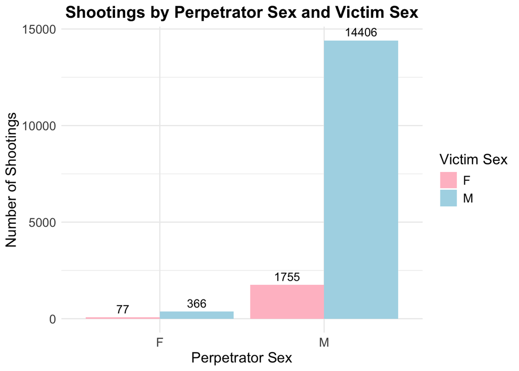

```r
defined_sex = c("M", "F")

shootings %>%
  filter(perp_sex %in% defined_sex,
         vic_sex %in% defined_sex) %>%
  count(perp_sex, vic_sex) %>%
  ggplot(aes(x = perp_sex, y = n, fill = vic_sex)) +
  geom_bar(stat = "identity", position = "dodge") +
  geom_text(aes(label = n), position = position_dodge(width = 0.9), vjust = -0.5, size = 4) +
  scale_fill_manual(values = c("F" = "pink", "M" = "lightblue")) +
  labs(
    title = "Shootings by Perpetrator Sex and Victim Sex",
    x = "Perpetrator Sex",
    y = "Number of Shootings",
    fill = "Victim Sex"
  ) +
  theme_minimal() +  # Clean and minimal theme
  theme(
    plot.title = element_text(hjust = 0.5, face = "bold", size = 16),
    axis.title = element_text(size = 14),  # Axis titles
    axis.text = element_text(size = 12),   # Axis labels
    legend.title = element_text(size = 14),  # Legend title
    legend.text = element_text(size = 12)   # Legend labels
  )
```

The first plot shows the dominance of male over female perpetrators, while still not clear if there is an effect of male perpetrators against female victims.

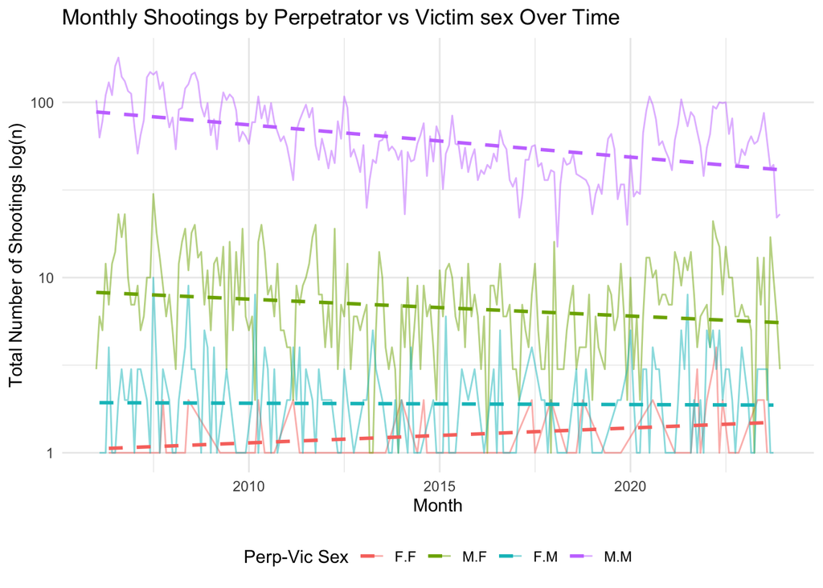

```r
shootings %>%
  filter(perp_sex %in% defined_sex,
         vic_sex %in% defined_sex,
        ) %>%
  mutate(month = floor_date(occur_date, "month")) %>%
  count(perp_sex, vic_sex, month) %>%
  ggplot(aes(x = month, y = n, color = interaction(perp_sex, vic_sex))) +
  geom_line(alpha=0.5) +  # Use geom_line() for a line chart
  scale_y_log10()+
  geom_smooth(method = "lm", se = FALSE, linetype = "dashed") +  # Add linear trend lines
  labs(
    title = "Monthly Shootings by Perpetrator vs Victim sex Over Time",
    x = "Month",
    y = "Total Number of Shootings log(n)",
    color = "Perp-Vic Sex"
  ) +
  theme_minimal() +
  theme(legend.position = "bottom")
```

In the second plot, you can observe the decrease of shootings over time overall, while female against female shootings have the only positive trend of all four comparisons.

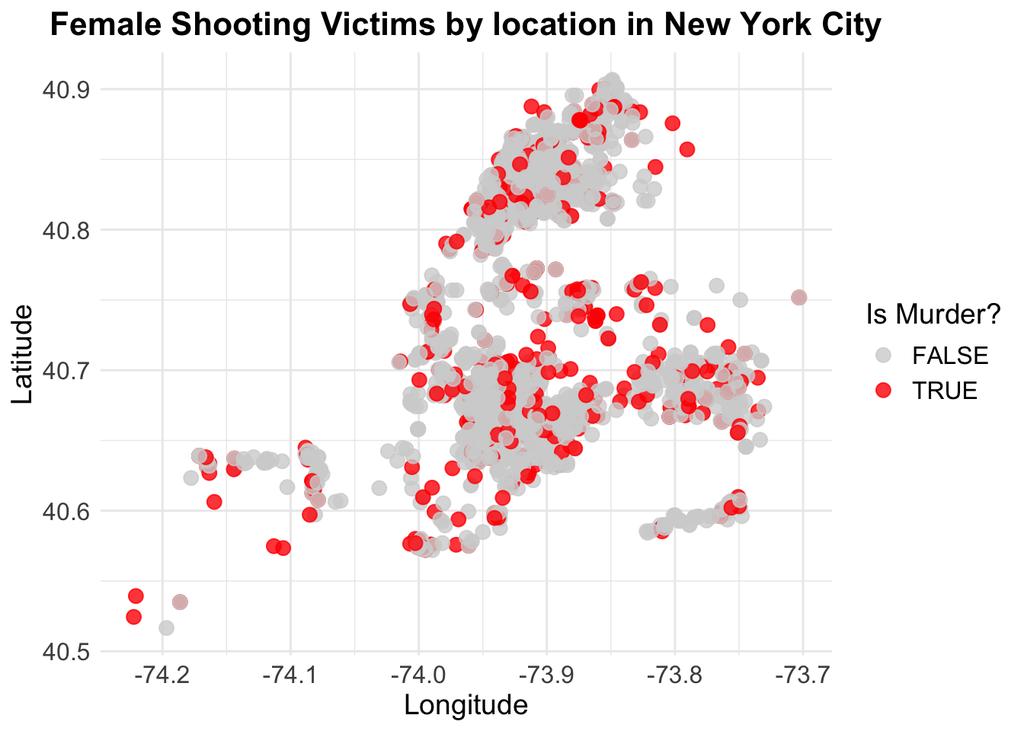

```r
shootings %>%
  filter(vic_sex == "F") %>%
  ggplot() +
  geom_point(aes(x = longitude, y = latitude, color = statistical_murder_flag), size = 3, alpha = 0.8) +
  scale_color_manual(values = c("TRUE" = "red", "FALSE" = "lightgray")) +
  labs(
    title = "Female Shooting Victims by location in New York City",
    x = "Longitude",
    y = "Latitude",
    color = "Is Murder?"
  ) +
  theme_minimal() +
  theme(
    plot.title = element_text(hjust = 0.5, face = "bold", size = 16),
    axis.title = element_text(size = 14),
    axis.text = element_text(size = 12),
    legend.title = element_text(size = 14),
    legend.text = element_text(size = 12)
  )
```

Finally, you can look at a map of the shootings filtered by Female victims. Where there is no clear safe zone of less murders occuring due to the red dots being distributed across all the map.

# Modeling the data

A model is provided below to further analyze the effect of sex over the number of shootings over time.

```r
mod_data <- shootings %>%
  filter(perp_sex %in% defined_sex,
         vic_sex %in% defined_sex,
        ) %>%
  mutate(month = floor_date(occur_date, "month")) %>%
  mutate(month_num = as.numeric(month - min(month)) / 30.44) %>%   # Months since start
  count(perp_sex, vic_sex, month_num)
mod <- lm(data = mod_data, n ~ month_num + perp_sex * vic_sex)
summary(mod)
```

```
##
## Call:
## lm(formula = n ~ month_num + perp_sex * vic_sex, data = mod_data)
##
## Residuals:
##     Min      1Q  Median      3Q     Max
## -48.424  -7.508  -1.227   5.882 104.550
##
## Coefficients:
##                    Estimate Std. Error t value Pr(>|t|)
## (Intercept)        11.27003    2.60135   4.332 1.71e-05 ***
## month_num          -0.08712    0.01069  -8.146 1.97e-15 ***
## perp_sexM           6.23806    2.58487   2.413   0.0161 *
## vic_sexM            0.44362    2.67560   0.166   0.8684
## perp_sexM:vic_sexM 58.10484    3.14902  18.452  < 2e-16 ***
## ---
## Signif. codes:  0 '***' 0.001 '**' 0.01 '*' 0.05 '.' 0.1 ' ' 1
##
## Residual standard error: 17.21 on 640 degrees of freedom
## Multiple R-squared:  0.7498, Adjusted R-squared:  0.7482
## F-statistic: 479.5 on 4 and 640 DF,  p-value: < 2.2e-16
```

## Key Model takeways

Time Trend: Shootings decrease by ~0.087 per month (p<0.001), suggesting a small but significant downward trend.

Sex Effects:

Male Perpetrators: Associated with significantly higher shootings when targeting female victims (baseline).

Male Victims: No significant effect when perpetrators are female (p=0.87).

Interaction: Male perpetrators targeting male victims drive a massive increase in shootings (58.10/month), indicating a strong synergistic effect.

Baseline: Female perpetrators targeting female victims are associated with ~11 shootings/month.

# Conclusion

With a quick glimpse of the data, you can identify males as a clear participant of New York City shootings. Since this could be a source of bias, models were interpreted to spotlight the effect of female perpetrators and victims. There was not a clear effect of these female participants increasing the count of shootings around New York through the analysis.